# SASC: Paired multiome, Part 2 (Kevin Lin)

June 17, 2025

# Loading packages

```r
library(Seurat)
library(Signac)
library(tiltedCCA)
library(ggplot2)
library(cowplot)
library(devtools)
```

# Loading the multiome dataset

This tutorial roughly follows [https://linnykos.github.io/tiltedCCA/articles/embryo.html](https://urldefense.com/v3/__https://linnykos.github.io/tiltedCCA/articles/embryo.html__;!!K-Hz7m0Vt54!l8z1cgLimWUehjP-UQXj91E35KMe10j2zUI4OsZMQE77jhZVMfT9o31RJUgPZ5_ownyYzyjCKD3Q$). We load a dataset downloaded from [https://www.dropbox.com/s/gh2om9eb5edgi14/10x_trevino_simplified.RData](https://urldefense.com/v3/__https://www.dropbox.com/s/gh2om9eb5edgi14/10x_trevino_simplified.RData__;!!K-Hz7m0Vt54!l8z1cgLimWUehjP-UQXj91E35KMe10j2zUI4OsZMQE77jhZVMfT9o31RJUgPZ5_ownyYz516qC-1$).

```r
load("/Users/kevinlin/Library/CloudStorage/Dropbox/Collaboration-and-People/sumie-katie/tutorial/sasc_2025/10x_trevino_simplified.RData")

seurat_obj
```

```
#> An object of class Seurat
#> 271643 features across 6158 samples within 2 assays
#> Active assay: SCT (2027 features, 2027 variable features)
#>  1 layer present: data
#>  1 other assay present: ATAC
```

# RNA dimension reduction

We first perform a typical dimension reduction and UMAP on the RNA modality. (SCTransform has already been used to normalize the counts.)

```r
set.seed(10)
Seurat::DefaultAssay(seurat_obj) <- "SCT"
seurat_obj <- Seurat::ScaleData(seurat_obj)
seurat_obj <- Seurat::RunPCA(seurat_obj,
                             verbose = FALSE)
seurat_obj <- Seurat::RunUMAP(seurat_obj,
                              dims = 1:50,
                              reduction.name = "umap.rna",
                              reduction.key = "rnaUMAP_")
```

[output not shown]

```r
seurat_obj
```

```
#> An object of class Seurat
#> 271643 features across 6158 samples within 2 assays
#> Active assay: SCT (2027 features, 2027 variable features)
#>  2 layers present: data, scale.data
#>  1 other assay present: ATAC
#>  2 dimensional reductions calculated: pca, umap.rna
```

# ATAC dimension reduction

Now we do this on the ATAC modality. Note that we typically remove the first latent dimension when constructing the UMAP, as done in https://stuartlab.org/signac/articles/pbmc_vignette#non-linear-dimension-reduction-and-clustering.

```r
# We exclude the first dimension as this is typically correlated with sequencing depth
set.seed(10)
seurat_obj <-  Signac::RunSVD(seurat_obj)
seurat_obj <- Seurat::RunUMAP(seurat_obj,
                              reduction = "lsi",
                              dims = 2:50,
                              reduction.name = "umap.atac",
                              reduction.key = "atacUMAP_")

seurat_obj <- tiltedCCA::rotate_seurat_embeddings(
  seurat_obj = seurat_obj,
  source_embedding = "umap.rna",
  target_embedding = "umap.atac"
)
```

```
#> Running SVD
#> Scaling cell embeddings
```

(As a side note, to illustrate that the leading latent dimension in `lsi` is correlated with the sequencing counts, we can make the following plots.)

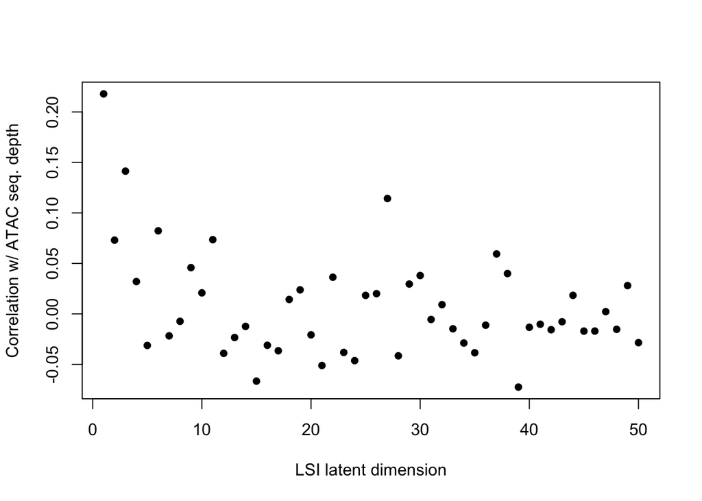

```r
lsi_mat <- seurat_obj[["lsi"]]@cell.embeddings
sequencing_depth <- seurat_obj$nCount_ATAC
cor_vec <- apply(lsi_mat, 2, function(x){stats::cor(x, sequencing_depth)})
plot(cor_vec, pch = 16, xlab = "LSI latent dimension", ylab = "Correlation w/ ATAC seq. depth")
```

```r
seurat_obj
```

```
#> An object of class Seurat
#> 271643 features across 6158 samples within 2 assays
#> Active assay: SCT (2027 features, 2027 variable features)
#>  2 layers present: data, scale.data
#>  1 other assay present: ATAC
#>  4 dimensional reductions calculated: pca, umap.rna, lsi, umap.atac
```

# Plotting

```r
col_palette <- c(
  "Cyc. Prog." = rgb(213, 163, 98, maxColorValue = 255),
  "GluN2" = rgb(122, 179, 232, maxColorValue = 255),
  "GluN3"= rgb(174, 198, 235, maxColorValue = 255),
  "GluN4" = rgb(217, 227, 132, maxColorValue = 255),
  "GluN5" = rgb(127, 175, 123, maxColorValue = 255),
  "nIPC/GluN1" = rgb(114, 169, 158, maxColorValue = 255),
  "RG" = rgb(197, 125, 95, maxColorValue = 255)
)
```

Now let’s visualize both modalities. This gives us a sense of what the “typical” modality looks like (i.e., no integration).

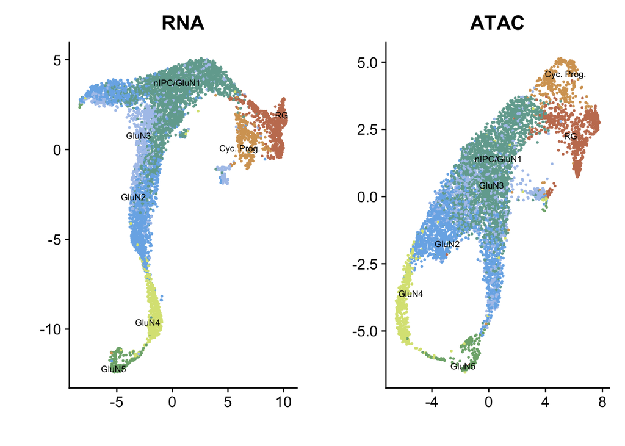

```r
p1 <- Seurat::DimPlot(seurat_obj,
                      reduction = "umap.rna",
                      group.by = "celltype",
                      cols = col_palette,
                      label = T, repel = T, label.size = 2.5)
p1 <- p1 + Seurat::NoLegend()
p1 <- p1 + ggplot2::ggtitle("RNA") + ggplot2::labs(x = "", y = "")
p1 <- p1 + ggplot2::theme(legend.text = ggplot2::element_text(size = 5))

p2 <- Seurat::DimPlot(seurat_obj,
                      reduction = "umap.atac",
                      group.by = "celltype",
                      cols = col_palette,
                      label = T, repel = T, label.size = 2.5)
p2 <- p2 + Seurat::NoLegend()
p2 <- p2 + ggplot2::ggtitle("ATAC") + ggplot2::labs(x = "", y = "")
p2 <- p2 + ggplot2::theme(legend.text = ggplot2::element_text(size = 5))

p_all <- cowplot::plot_grid(p1, p2, ncol = 2)
p_all
```

# WNN

We follow the tutorial in [https://satijalab.org/seurat/articles/weighted_nearest_neighbor_analysis](https://urldefense.com/v3/__https://satijalab.org/seurat/articles/weighted_nearest_neighbor_analysis__;!!K-Hz7m0Vt54!l8z1cgLimWUehjP-UQXj91E35KMe10j2zUI4OsZMQE77jhZVMfT9o31RJUgPZ5_ownyYz4NSI8Aw$). The intent of the Weighted Nearest Neighbor (WNN) method is to create **one** UMAP that combines the variation in either the RNA or ATAC modality (i.e., the “union” of information). This is useful because it gives us a bird’s eye view of both modalities in one plot – cell separation patterns in either RNA or ATAC would show up in the WNN UMAP.

Note that this method is not specific to RNA or ATAC modalities. It simply requies two embeddings for paired modalities (i.e., two modalities measured on the same cells).

See https://www.cell.com/cell/fulltext/S0092-8674(21)00583-3 for more information.

```r
seurat_obj <- Seurat::FindMultiModalNeighbors(seurat_obj,
                                              reduction.list = list("pca", "lsi"),
                                              dims.list = list(1:50, 2:50))
seurat_obj <- Seurat::RunUMAP(seurat_obj,
                              nn.name = "weighted.nn",
                              reduction.name = "wnn.umap",
                              reduction.key = "wnnUMAP_")
```

```
#> Calculating cell-specific modality weights
#> Finding 20 nearest neighbors for each modality.
#> Calculating kernel bandwidths
#> Finding multimodal neighbors
#> Constructing multimodal KNN graph
#> Constructing multimodal SNN graph
```

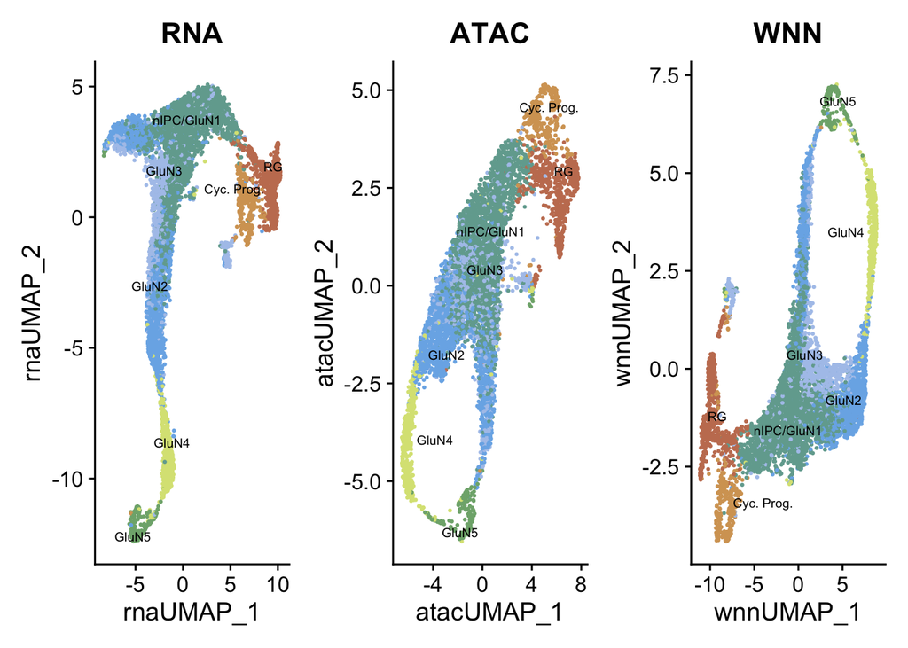

```r
p1 <- Seurat::DimPlot(seurat_obj,
              reduction = "umap.rna",
              group.by = "celltype",
              cols = col_palette,
              label = TRUE,
              label.size = 2.5,
              repel = TRUE) + ggtitle("RNA")
p2 <- Seurat::DimPlot(seurat_obj,
                      reduction = "umap.atac",
                      group.by = "celltype",
                      cols = col_palette,
                      label = TRUE,
                      label.size = 2.5,
                      repel = TRUE) + ggtitle("ATAC")
p3 <- Seurat::DimPlot(seurat_obj,
                      reduction = "wnn.umap",
                      group.by = "celltype",
                      cols = col_palette,
                      label = TRUE,
                      label.size = 2.5,
                      repel = TRUE) + ggtitle("WNN")
p1 + p2 + p3 & Seurat::NoLegend() & theme(plot.title = element_text(hjust = 0.5))
```

```r
seurat_obj
```

```
#> An object of class Seurat
#> 271643 features across 6158 samples within 2 assays
#> Active assay: SCT (2027 features, 2027 variable features)
#>  2 layers present: data, scale.data
#>  1 other assay present: ATAC
#>  5 dimensional reductions calculated: pca, umap.rna, lsi, umap.atac, wnn.umap
```

# Tilted-CCA

What if, in contrast, we want to separate which sources of variation are **shared** between the RNA and ATAC modalities, as well as which additional variations in one modalities are “invisible” to the other? This is where we could use Tilted-CCA to aid us.

We follow the tutorial from [https://linnykos.github.io/tiltedCCA/articles/embryo.html](https://urldefense.com/v3/__https://linnykos.github.io/tiltedCCA/articles/embryo.html__;!!K-Hz7m0Vt54!l8z1cgLimWUehjP-UQXj91E35KMe10j2zUI4OsZMQE77jhZVMfT9o31RJUgPZ5_ownyYzyjCKD3Q$).

See https://www.pnas.org/doi/10.1073/pnas.2303647120 for more information.

```r
# https://linnykos.github.io/tiltedCCA/articles/embryo.html

Seurat::DefaultAssay(seurat_obj) <- "SCT"
mat_1 <- Matrix::t(seurat_obj[["SCT"]]@data)
Seurat::DefaultAssay(seurat_obj) <- "ATAC"
mat_2 <- Matrix::t(seurat_obj[["ATAC"]]@data)

mat_1b <- mat_1
sd_vec <- sparseMatrixStats::colSds(mat_1b)
if(any(sd_vec <= 1e-6)){
  mat_1b <- mat_1b[,-which(sd_vec <= 1e-6)]
}

mat_2b <- mat_2
sd_vec <- sparseMatrixStats::colSds(mat_2b)
if(any(sd_vec <= 1e-6)){
  mat_2b <- mat_2b[,-which(sd_vec <= 1e-6)]
}
```

The first step of TCCA might take a while, since this first step computes the low-dimensional embeddings in its own way.

```r
set.seed(10)
multiSVD_obj <- tiltedCCA::create_multiSVD(mat_1 = mat_1b, mat_2 = mat_2b,
                                           dims_1 = 1:50, dims_2 = 2:50,
                                           center_1 = T, center_2 = F,
                                           normalize_row = T,
                                           normalize_singular_value = T,
                                           recenter_1 = F, recenter_2 = T,
                                           rescale_1 = F, rescale_2 = T,
                                           scale_1 = T, scale_2 = F,
                                           verbose = 1)
```

The following steps are simplified to speed up the calculations for this tutorial.

```r
multiSVD_obj <- tiltedCCA::form_metacells(input_obj = multiSVD_obj,
                                          large_clustering_1 = NULL,
                                          large_clustering_2 = NULL,
                                          num_metacells = 100,
                                          verbose = 1)

multiSVD_obj <- tiltedCCA::compute_snns(input_obj = multiSVD_obj,
                                        latent_k = 20,
                                        num_neigh = 15,
                                        bool_cosine = T,
                                        bool_intersect = F,
                                        min_deg = 15,
                                        verbose = 1)

multiSVD_obj2 <- tiltedCCA::tiltedCCA(input_obj = multiSVD_obj,
                                      discretization_gridsize = 5, # set to be lower to speed up the calculation for sake of the tutorial
                                      verbose = 1)

multiSVD_obj2 <- tiltedCCA::fine_tuning(input_obj = multiSVD_obj2,
                                        max_iter = 3, # set to be lower to speed up the calculation for sake of the tutorial
                                        verbose = 1)

multiSVD_obj2 <- tiltedCCA::tiltedCCA_decomposition(input_obj = multiSVD_obj2,
                                                    verbose = 1,
                                                    bool_modality_1_full = T,
                                                    bool_modality_2_full = F)
```

```
#> [1] "Extracting SVD"
#> [1] "Computing large clusterings with 10 clusters"
#> [1] "Computing intersection of clusterings"
#> [1] "Computing metacells"
#> [1] "Constructin SNN 1"
#> [1] "Constructin SNN 2"
#> [1] "Constructin common SNN"
#> [1] "Getting NN information"
#> [1] "Determining common NN's"
#> [1] "Computing symmetrized Laplacians"
#> [1] "Converting to random walk Laplacian"
#> [1] "Extracting basis"
#> [1] "Computing symmetrized Laplacians"
#> [1] "Converting to random walk Laplacian"
#> [1] "Extracting basis"
```

[output cut: 326 more lines]

```r
names(multiSVD_obj2)
```

```
#>  [1] "svd_1"             "svd_2"             "default_assay"
#>  [4] "param"             "metacell_obj"      "snn_list"
#>  [7] "laplacian_list"    "cca_obj"           "tcca_obj"
#> [10] "common_mat_1"      "distinct_mat_1"    "common_dimred_2"
#> [13] "distinct_dimred_2"
```

We can now visualize the common embedding (`common_tcca`, showing the variations in both RNA and ATAC), and the two distinct embeddings (`distinct1_tcca` for the additional unique variation in RNA not in ATAC, and `distinct2_tcca` for the additional unique variation in ATAC not in RNA).

```r
set.seed(10)
seurat_obj[["common_tcca"]] <- tiltedCCA::create_SeuratDim(input_obj = multiSVD_obj2,
                                                           what = "common",
                                                           aligned_umap_assay = "umap.rna",
                                                           seurat_obj = seurat_obj,
                                                           seurat_assay = "SCT",
                                                           verbose = 1)
set.seed(10)
seurat_obj[["distinct1_tcca"]] <- tiltedCCA::create_SeuratDim(input_obj = multiSVD_obj2,
                                                              what = "distinct_1",
                                                              aligned_umap_assay = "umap.rna",
                                                              seurat_obj = seurat_obj,
                                                              seurat_assay = "SCT",
                                                              verbose = 1)
set.seed(10)
seurat_obj[["distinct2_tcca"]] <- tiltedCCA::create_SeuratDim(input_obj = multiSVD_obj2,
                                                              what = "distinct_2",
                                                              aligned_umap_assay = "umap.rna",
                                                              seurat_obj = seurat_obj,
                                                              seurat_assay = "SCT",
                                                              verbose = 1)
```

```
#> Warning: Key 'UMAP_' taken, using 'distinct1tcca_' instead
#> Warning: Key 'UMAP_' taken, using 'distinct2tcca_' instead
```

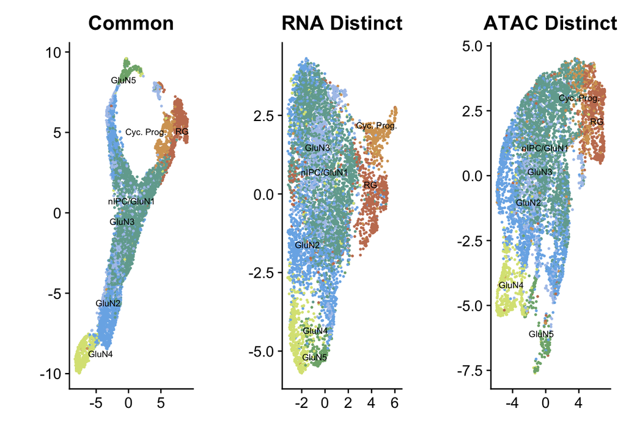

```r
p1 <- Seurat::DimPlot(seurat_obj,
                      reduction = "common_tcca",
                      group.by = "celltype",
                      cols = col_palette,
                      label = T, repel = T, label.size = 2.5)
p1 <- p1 + Seurat::NoLegend()
p1 <- p1 + ggplot2::ggtitle("Common") + ggplot2::labs(x = "", y = "")
p1 <- p1 + ggplot2::theme(legend.text = ggplot2::element_text(size = 5))

p2 <- Seurat::DimPlot(seurat_obj,
                      reduction = "distinct1_tcca",
                      group.by = "celltype",
                      cols = col_palette,
                      label = T, repel = T, label.size = 2.5)
p2 <- p2 + Seurat::NoLegend()
p2 <- p2 + ggplot2::ggtitle("RNA Distinct") + ggplot2::labs(x = "", y = "")
p2 <- p2 + ggplot2::theme(legend.text = ggplot2::element_text(size = 5))

p3 <- Seurat::DimPlot(seurat_obj,
                      reduction = "distinct2_tcca",
                      group.by = "celltype",
                      cols = col_palette,
                      label = T, repel = T, label.size = 2.5)
p3 <- p3 + Seurat::NoLegend()
p3 <- p3 + ggplot2::ggtitle("ATAC Distinct") + ggplot2::labs(x = "", y = "")
p3 <- p3 + ggplot2::theme(legend.text = ggplot2::element_text(size = 5))

p_all <- cowplot::plot_grid(p1, p2, p3, ncol = 3)
p_all
```

Equipped with this, we can visualize the **synchrony score** for each cell. This could help us understand epigenetic priming – the pre-configuring of a cell’s chromatin so that key developmental genes are kept in a poised, low-level accessible state; this “molecular bookmark” enables rapid and lineage-specific activation (or repression) of those genes when differentiation cues arrive, thereby guiding cells toward their future identities with both speed and fidelity.

This can be computed by comparing each cell’s low-dimension vector in the common embedding to the corresponding vectors in distinct embeddings. A high synchrony score means that the two modalities are “aligned” (based on some statistical definition) in both modalities, while a low score means that there is information in one modality not reflected in the other.

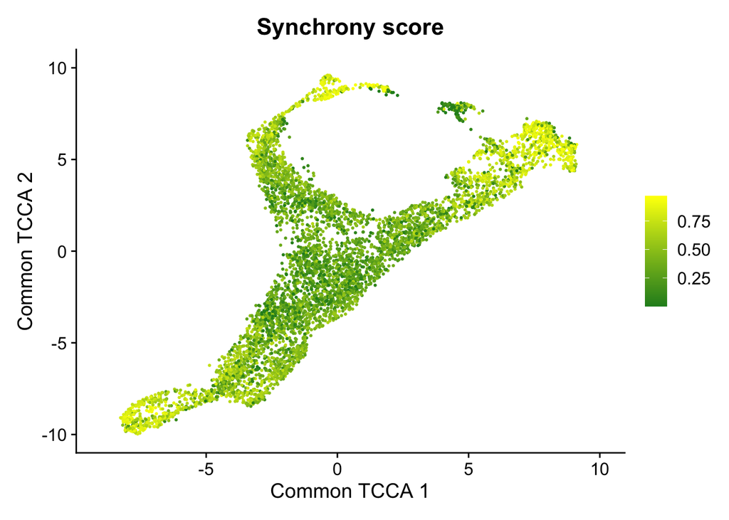

```r
synchrony_score <- tiltedCCA::compute_synchrony(input_obj = multiSVD_obj2)

seurat_obj$synchrony <- synchrony_score[Seurat::Cells(seurat_obj),"synchrony_rescaled"]

p1 <- Seurat::FeaturePlot(seurat_obj,
                    reduction = "common_tcca",
                    feature = "synchrony",
                    cols = c("forestgreen", "yellow"))
p1 <- p1 + ggplot2::ggtitle("Synchrony score") + ggplot2::labs(x = "Common TCCA 1", y = "Common TCCA 2")
p1
```

```r
seurat_obj
```

```
#> An object of class Seurat
#> 271643 features across 6158 samples within 2 assays
#> Active assay: ATAC (269616 features, 269616 variable features)
#>  1 layer present: data
#>  1 other assay present: SCT
#>  8 dimensional reductions calculated: pca, umap.rna, lsi, umap.atac, wnn.umap, common_tcca, distinct1_tcca, distinct2_tcca
```